# Lab 02 - Plastic waste

Cat Seitz

01/16/23

## Load packages and data

```r
library(tidyverse)
library(ggplot2)
library(viridis)
```

```r
plastic_waste <- read.csv("data/plastic-waste.csv")
```

## Exercises

### Exercise 1

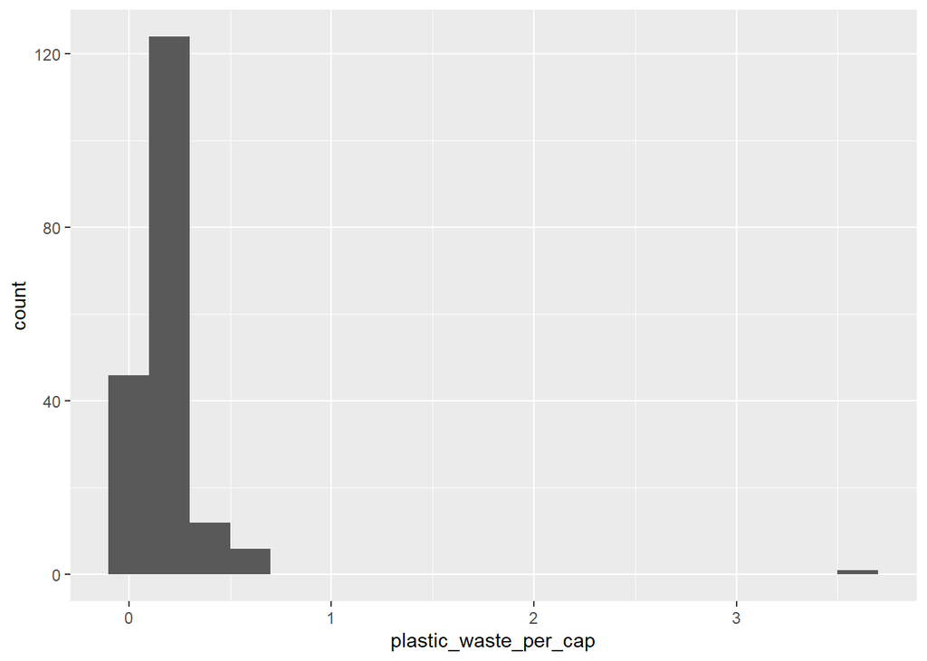

```r
ggplot(data = plastic_waste, aes(x = plastic_waste_per_cap)) +
  geom_histogram(binwidth = 0.2)
```

```r
plastic_waste %>%
  filter(plastic_waste_per_cap > 3.5)
```

```
##   code              entity     continent year gdp_per_cap plastic_waste_per_cap
## 1  TTO Trinidad and Tobago North America 2010    31260.91                   3.6
##   mismanaged_plastic_waste_per_cap mismanaged_plastic_waste coastal_pop
## 1                             0.19                    94066     1358433
##   total_pop
## 1   1341465
```

I wasn’t expecting this result, but upon further investigation, I found that Trinidad and Tobago has inefficient waste management systems and the households don’t segregate waste.

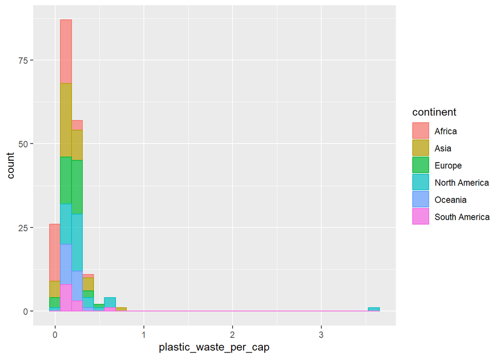

```r
ggplot(data = plastic_waste,
       mapping = aes(x = plastic_waste_per_cap,
                     color = continent,
                     fill = continent)) +
  geom_histogram(alpha = 0.7)
```

### Exercise 2.1

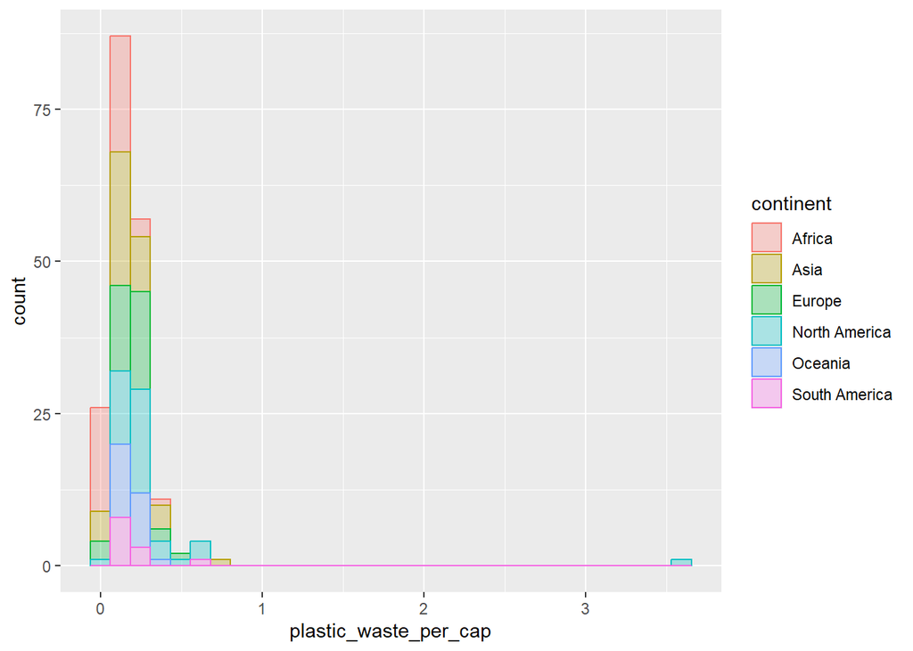

```r
ggplot(data = plastic_waste,
       mapping = aes(x = plastic_waste_per_cap,
                     color = continent,
                     fill = continent)) +
  geom_histogram(alpha = 0.3)
```

### Exercise 2.2

The color and fill are defined by the continent so the dataframe gets grouped that way instead of all of the continents grouped together, but alpha is a function of the entire graph.

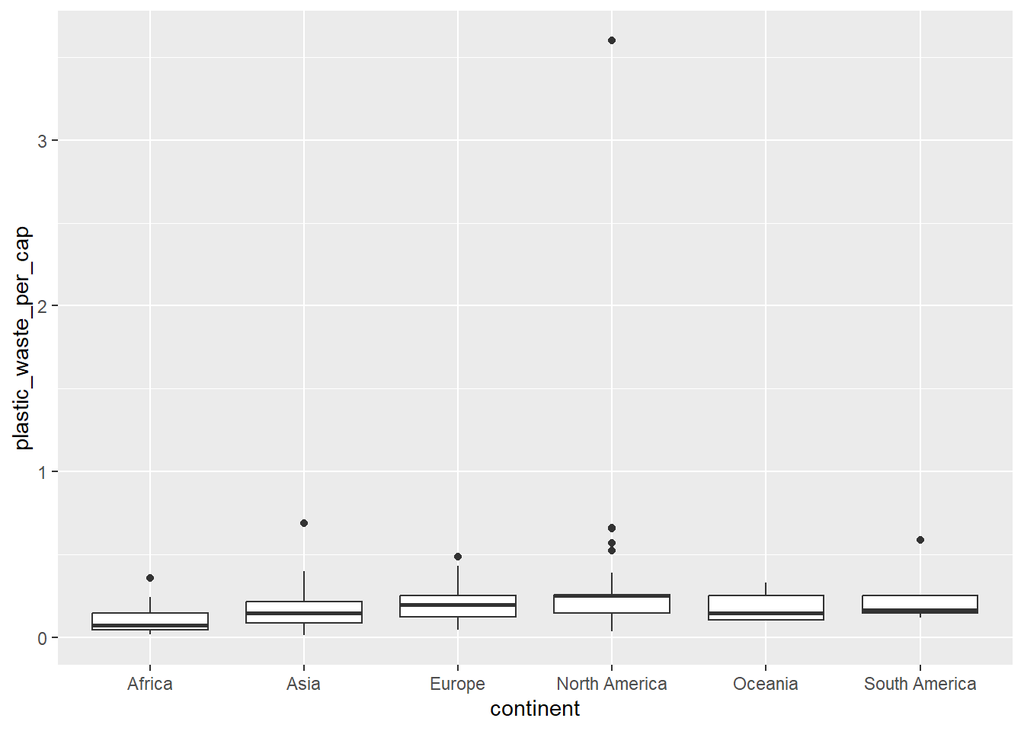

```r
ggplot(data = plastic_waste,
       mapping = aes(x = continent,
                     y = plastic_waste_per_cap)) +
  geom_boxplot()
```

### Exercise 3.1

Violin plots show the density of the distribution as well as all of the elements of the box plot.

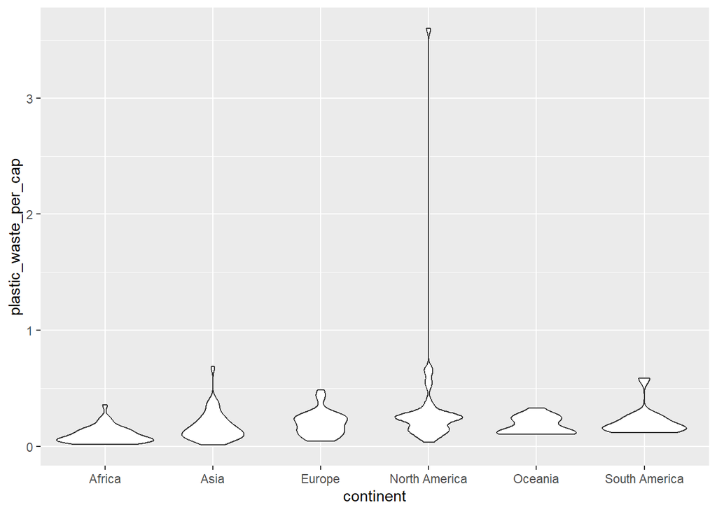

```r
ggplot(data = plastic_waste,
       mapping = aes(x = continent,
                     y = plastic_waste_per_cap)) +
  geom_violin()
```

### Exercise 4.1

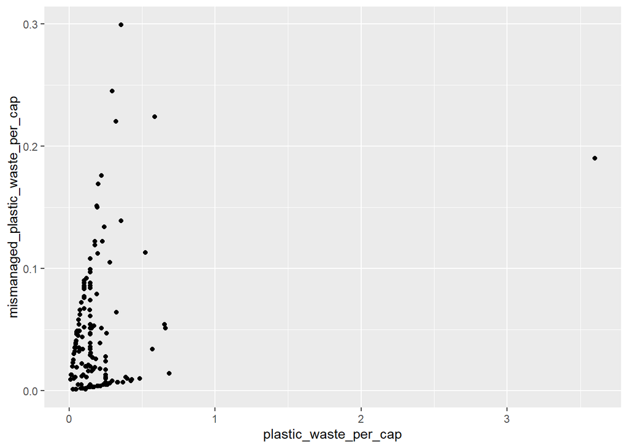

```r
ggplot(data = plastic_waste,
       mapping = aes(x = plastic_waste_per_cap,
                     y = mismanaged_plastic_waste_per_cap)) +
  geom_point()
```

There seems to be a positive correlation between between plastic waste per capita and mismanaged waste per capita.

### Exercise 4.2

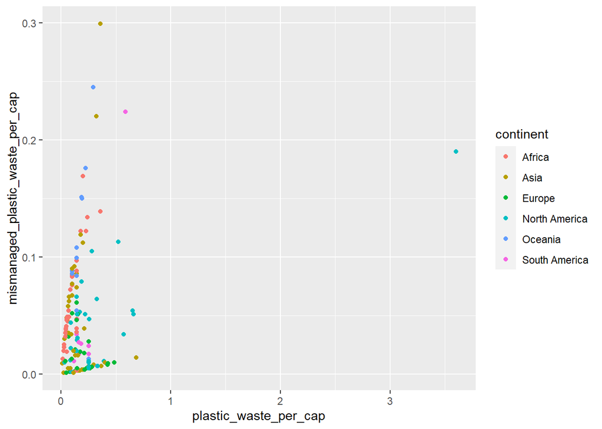

```r
ggplot(data = plastic_waste,
       mapping = aes(x = plastic_waste_per_cap,
                     y = mismanaged_plastic_waste_per_cap,
                     color=continent))+
  geom_point()
```

It’s somewhat hard to tell because most of the data points are confined to the same area, but it looks like some continents have steeper relationships between plastic waste per capita and mismanaged waste per capita. If I has to speculate, Europe has a less steep relationship and Africa has a more steep relationship.

### Exercise 4.3

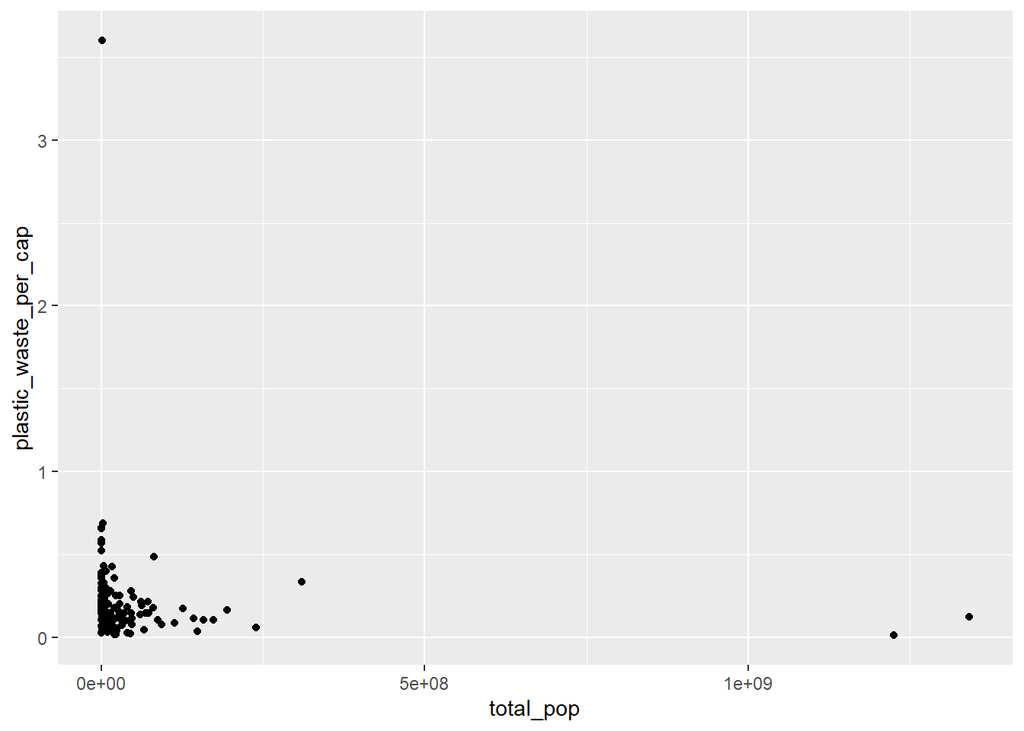

```r
ggplot(data = plastic_waste,
       mapping = aes(x = total_pop,
                     y = plastic_waste_per_cap))+
  geom_point()
```

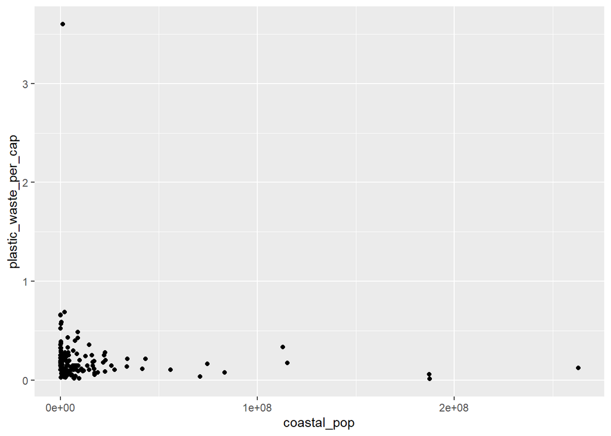

```r
ggplot(data = plastic_waste,
       mapping = aes(x = coastal_pop,
                     y = plastic_waste_per_cap))+
  geom_point()
```

Plastic waste per capita and coastal population seem to be more linearly associated than plastic waste per capita and total population, but, again, it’s difficult to tell just from these scatterplots.

### Exercise recreate plot

```r
plastic_waste <- transform(
  plastic_waste, coastal_pop_proportion= plastic_waste$coastal_pop/plastic_waste$total_pop
)
```

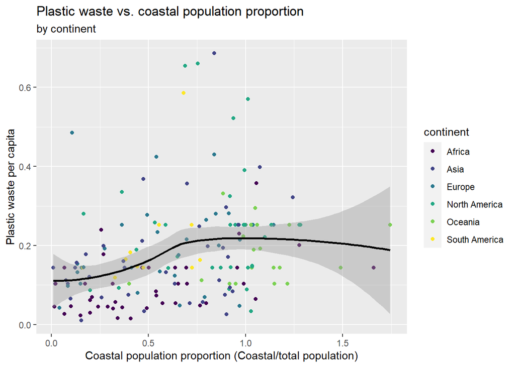

```r
ggplot(plastic_waste[which(plastic_waste$plastic_waste_per_cap<3.5),],
       mapping = aes(x = coastal_pop_proportion,
                     y = plastic_waste_per_cap))+
  geom_point(aes(color=continent))+
  geom_smooth(color="#000000")+
  scale_color_viridis(discrete=TRUE)+

  labs(title = "Plastic waste vs. coastal population proportion", subtitle = "by continent")+
  labs(x = "Coastal population proportion (Coastal/total population)", y = "Plastic waste per capita")
```